# Milestone 3

2023-10-17

```r
library(statsr)
library(dplyr)
```

```r
library(ggplot2)
library(readr)
library(multcomp)
setwd("/Users/oscarfs/GitHub/SQL-Capstone_Project")
```

```r
df <- read_csv("export.csv")
df$Medal[is.na(df$Medal)] <- "No medal"    # Change NA's to No medal.
df$Medal <- as.factor(df$Medal)

summary(df)
```

```
##        ID             Sex                 Age            Height
##  Min.   :    34   Length:24407       Min.   :12.00   Min.   :146.0
##  1st Qu.: 34574   Class :character   1st Qu.:20.00   1st Qu.:171.0
##  Median : 69202   Mode  :character   Median :23.00   Median :178.0
##  Mean   : 68716                      Mean   :23.58   Mean   :177.7
##  3rd Qu.:102686                      3rd Qu.:26.00   3rd Qu.:184.0
##  Max.   :135563                      Max.   :52.00   Max.   :208.0
##      Weight         Country               Year         Sport
##  Min.   : 35.00   Length:24407       Min.   :1896   Length:24407
##  1st Qu.: 61.00   Class :character   1st Qu.:1968   Class :character
##  Median : 69.00   Mode  :character   Median :1988   Mode  :character
##  Mean   : 70.54                      Mean   :1983
##  3rd Qu.: 78.00                      3rd Qu.:2004
##  Max.   :160.00                      Max.   :2016
##       Medal
##  Bronze  : 1535
##  Gold    : 1899
##  No medal:19349
##  Silver  : 1624
##
##
```

## Effect of Age on performance

From the previous milestone, we remember that we saw some differences between the different classes with age. The next step is to compare them and find if the differences are significant.

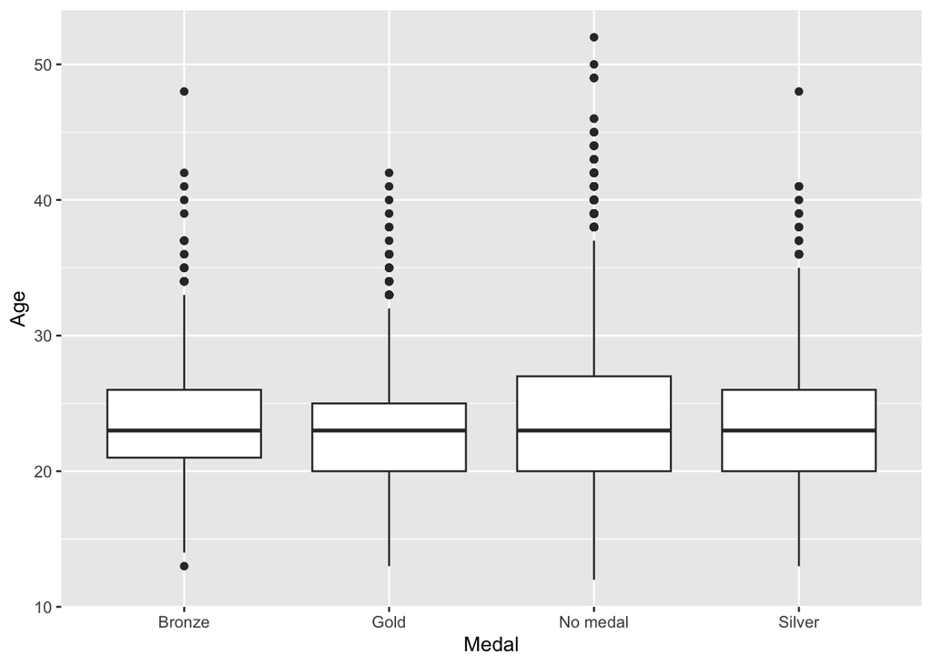

```r
ggplot(data = df, aes(x = Medal, y = Age)) + geom_boxplot()
```

These are the medias of the age per group.

```r
df %>% group_by(df$Medal) %>%
  summarise(mean = mean(Age), SD = sd(Age))
```

```
## # A tibble: 4 × 3
##   `df$Medal`  mean    SD
##   <fct>      <dbl> <dbl>
## 1 Bronze      23.3  4.28
## 2 Gold        23.0  4.23
## 3 No medal    23.7  4.75
## 4 Silver      23.2  4.45
```

We will conduct an Analysis of Variance (ANOVA) since we have more than two means. We also need to adjust the $\alpha$ value with the Bonferroni correction. So the new p_value is calculated as $\alpha / K$, where $K = \dfrac{k(k-1)}{2}$. So, the new p-value is:

```r
# New p-value.
0.05/(4*3/2)
```

```
## [1] 0.008333333
```

The results of the ANOVA test are the following:

```r
inference(y = Age, x = Medal, data = df, statistic = "mean", type = "ht", conf_level = 0.95, null = 0, alternative = "greater", method = "theoretical", order = c("Gold", "Silver", "Bronze", "No medal"))
```

```
## Response variable: numerical
## Explanatory variable: categorical (4 levels)
## n_Bronze = 1535, y_bar_Bronze = 23.2984, s_Bronze = 4.2837
## n_Gold = 1899, y_bar_Gold = 22.9937, s_Gold = 4.2318
## n_No medal = 19349, y_bar_No medal = 23.6983, s_No medal = 4.7545
## n_Silver = 1624, y_bar_Silver = 23.1909, s_Silver = 4.4537
##
## ANOVA:
##              df      Sum_Sq  Mean_Sq       F  p_value
## Medal         3   1290.6426 430.2142 19.7452 < 0.0001
## Residuals 24403 531698.6479  21.7882
## Total     24406 532989.2905
##
## Pairwise tests - t tests with pooled SD:
## # A tibble: 6 × 3
##   group1   group2    p.value
##   <chr>    <chr>       <dbl>
## 1 Gold     Bronze   5.72e- 2
## 2 No medal Bronze   1.24e- 3
## 3 No medal Gold     3.51e-10
## 4 Silver   Bronze   5.18e- 1
## 5 Silver   Gold     2.11e- 1
## 6 Silver   No medal 2.59e- 5
```

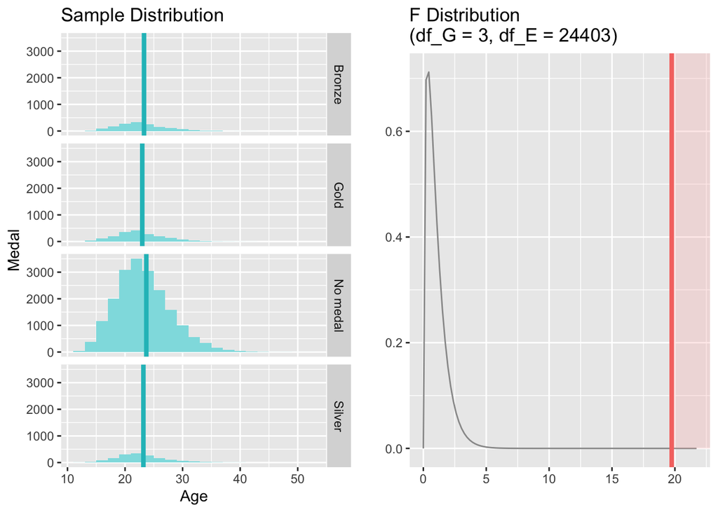

From these results we can notice that the p-value is less than 0.0001. Therefore, we can conclude that there is at least one pair of means where the difference is significant.

Therefore, age might play a role in the probability of performing better in any sport.

### Simplifying the performance metric

We now have two classes: Medalist or not medalist.

```r
df2 <- df
df2$Medal = ifelse(df$Medal == 'No medal', "No", "Yes")
df2$Medal = as.factor(df2$Medal)

summary(df2)
```

```
##        ID             Sex                 Age            Height
##  Min.   :    34   Length:24407       Min.   :12.00   Min.   :146.0
##  1st Qu.: 34574   Class :character   1st Qu.:20.00   1st Qu.:171.0
##  Median : 69202   Mode  :character   Median :23.00   Median :178.0
##  Mean   : 68716                      Mean   :23.58   Mean   :177.7
##  3rd Qu.:102686                      3rd Qu.:26.00   3rd Qu.:184.0
##  Max.   :135563                      Max.   :52.00   Max.   :208.0
##      Weight         Country               Year         Sport
##  Min.   : 35.00   Length:24407       Min.   :1896   Length:24407
##  1st Qu.: 61.00   Class :character   1st Qu.:1968   Class :character
##  Median : 69.00   Mode  :character   Median :1988   Mode  :character
##  Mean   : 70.54                      Mean   :1983
##  3rd Qu.: 78.00                      3rd Qu.:2004
##  Max.   :160.00                      Max.   :2016
##  Medal
##  No :19349
##  Yes: 5058
##
##
##
##
```

The differences in the mean are slight, but still we can see that medalist are slightly younger.

```r
df2 %>% group_by(Medal) %>%
  summarise(mean = mean(Age), SD = sd(Age))
```

```
## # A tibble: 2 × 3
##   Medal  mean    SD
##   <fct> <dbl> <dbl>
## 1 No     23.7  4.75
## 2 Yes    23.1  4.32
```

The difference is significant with p-value less than 0.0001. Therefore, younger athletes tend to perform better than older athletes.

```r
inference(y = Age, x = Medal, data = df2, statistic = "mean", type = "ht", null = 0, alternative = "greater", method = "theoretical")
```

```
## Response variable: numerical
## Explanatory variable: categorical (2 levels)
## n_No = 19349, y_bar_No = 23.6983, s_No = 4.7545
## n_Yes = 5058, y_bar_Yes = 23.1495, s_Yes = 4.3209
## H0: mu_No =  mu_Yes
## HA: mu_No > mu_Yes
## t = 7.8728, df = 5057
## p_value = < 0.0001
```

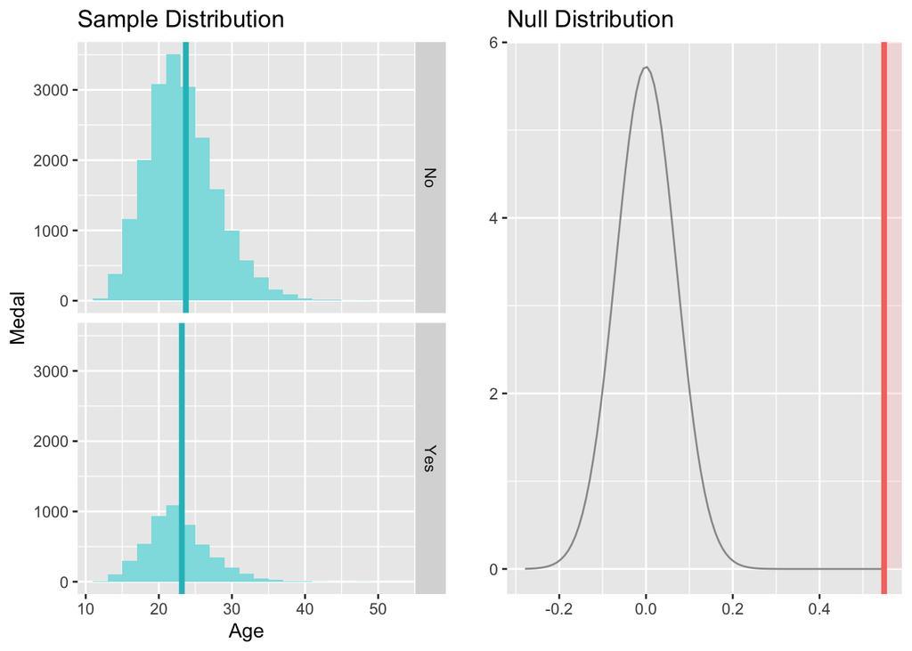

## New metric: Body Mass Index (BMI)

We can see that Height and Weight have a strong positive correlation. We decided to join both attributes into a new metric that shows the meassure of both: the BMI. This is calculated as $BMI = \dfrac{Weight}{Height^2}$. The units are km/m$^2$.

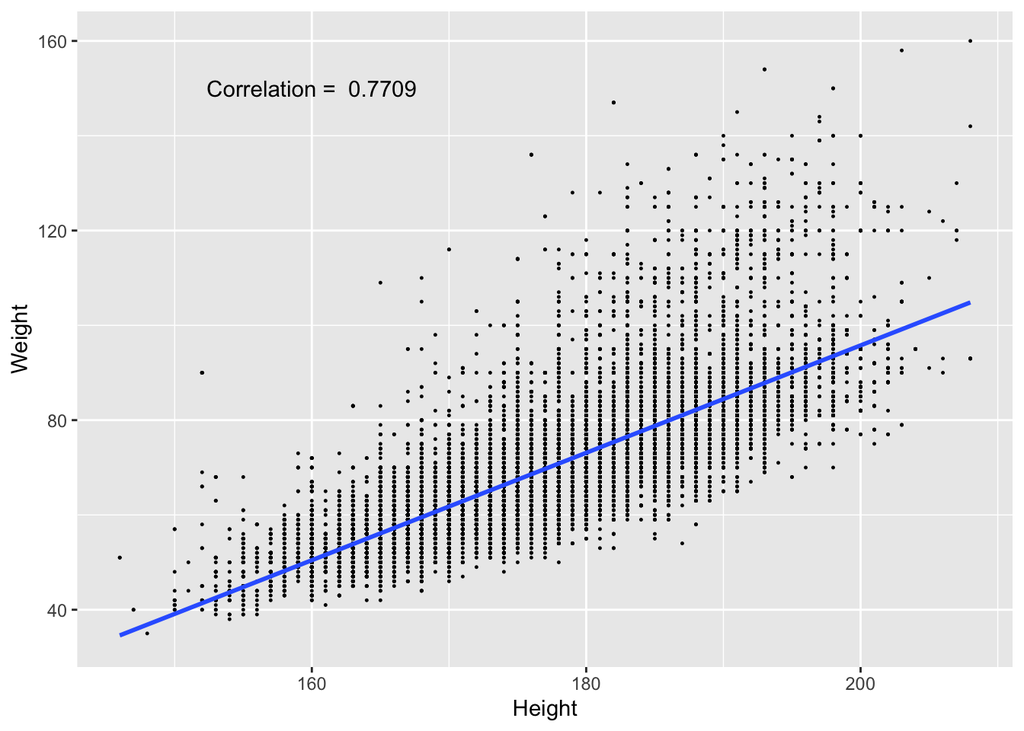

```r
ggplot(data = df, aes(x = Height, y = Weight)) +
  geom_point(size = 0.2) +
  geom_smooth(method = "lm") +
  annotate("text",
    x = 160, y = 150,
    label = paste("Correlation = ", round(cor(df$Height, df$Weight, method = "pearson"), 4)))
```

```r
df <- df %>%
    mutate(BMI = Weight / (Height / 100) ** 2)

head(df, n = 10)
```

```
## # A tibble: 10 × 10
##       ID Sex     Age Height Weight Country    Year Sport     Medal      BMI
##    <dbl> <chr> <dbl>  <dbl>  <dbl> <chr>     <dbl> <chr>     <fct>    <dbl>
##  1   259 F        21    173     59 Canada     1984 Swimming  No medal  19.7
##  2   449 F        26    164     58 Russia     2008 Athletics No medal  21.6
##  3   460 M        22    190     78 Russia     1972 Swimming  No medal  21.6
##  4   587 F        26    178     61 Germany    1988 Athletics No medal  19.3
##  5   650 M        18    182     68 Canada     2016 Swimming  No medal  20.5
##  6   737 F        33    188     66 USA        2008 Athletics No medal  18.7
##  7   747 M        22    179     60 Japan      1936 Athletics No medal  18.7
##  8   803 F        16    165     54 UK         1976 Swimming  No medal  19.8
##  9   824 M        31    189     70 Australia  2008 Athletics No medal  19.6
## 10   836 M        23    188     78 USA        1908 Athletics No medal  22.1
```

There is no strong correlation between Age and the new metric. The higher the performance, the higher the correlation, but this is not very strong.

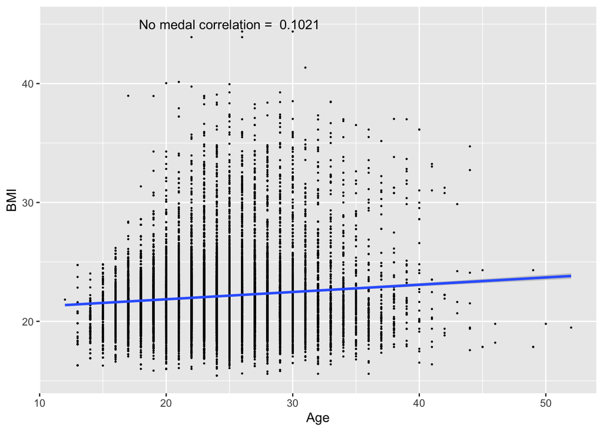

```r
aux_df <- df[df$Medal == "No medal", ]
ggplot(data = aux_df, aes(x = Age, y = BMI)) +
  geom_point(size = 0.2) +
  geom_smooth(method = "lm") +
  annotate("text",
    x = 25, y = 45,
    label = paste("No medal correlation = ", round(cor(aux_df$Age, aux_df$BMI, method = "pearson"), 4)))
```

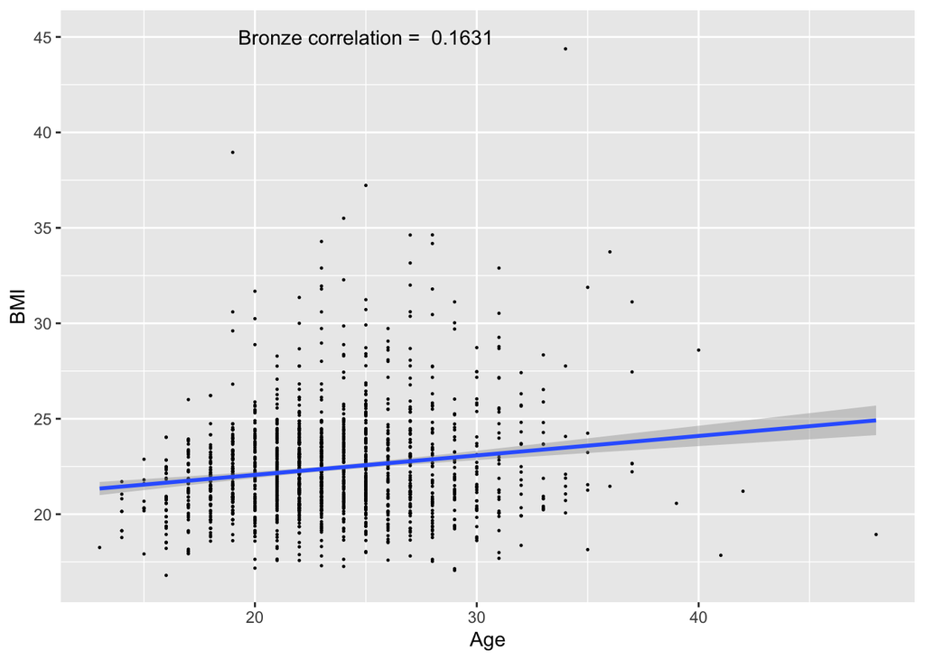

```r
aux_df = df[df$Medal == "Bronze", ]
ggplot(data = aux_df, aes(x = Age, y = BMI)) +
  geom_point(size = 0.2) +
  geom_smooth(method = "lm") +
  annotate("text",
    x = 25, y = 45,
    label = paste("Bronze correlation = ", round(cor(aux_df$Age, aux_df$BMI, method = "pearson"), 4)))
```

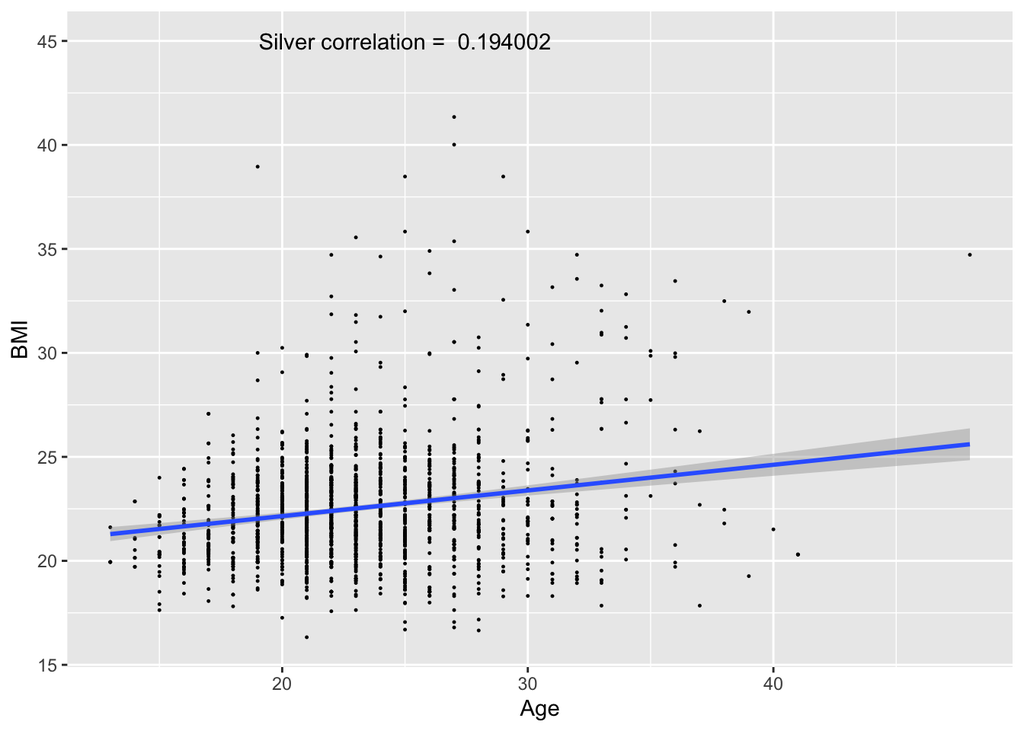

```r
aux_df = df[df$Medal == "Silver", ]
ggplot(data = aux_df, aes(x = Age, y = BMI)) +
  geom_point(size = 0.2) +
  geom_smooth(method = "lm") +
  annotate("text",
    x = 25, y = 45,
    label = paste("Silver correlation = ", round(cor(aux_df$Age, aux_df$BMI, method = "pearson"), 6)))
```

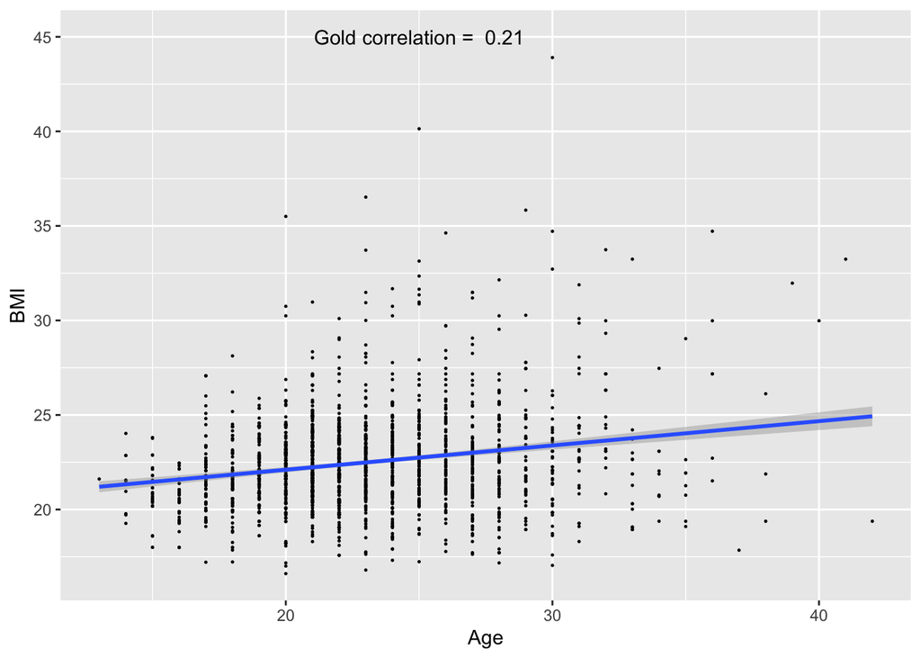

```r
aux_df = df[df$Medal == "Gold", ]
ggplot(data = aux_df, aes(x = Age, y = BMI)) +
  geom_point(size = 0.2) +
  geom_smooth(method = "lm") +
  annotate("text",
    x = 25, y = 45,
    label = paste("Gold correlation = ", round(cor(aux_df$Age, aux_df$BMI, method = "pearson"), 4)))
```

With these new metric, there seems to be a difference in the BMI for each performance group.

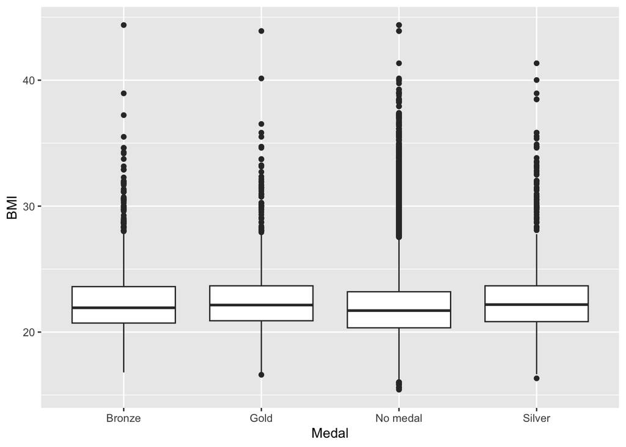

```r
ggplot(data = df, aes(x = Medal, y = BMI)) + geom_boxplot()
```

It seems that top athletes have a higher BMI than athletes without medals.

```r
df %>% group_by(Medal) %>%
  summarise(mean = mean(BMI), SD = sd(BMI))
```

```
## # A tibble: 4 × 3
##   Medal     mean    SD
##   <fct>    <dbl> <dbl>
## 1 Bronze    22.4  2.68
## 2 Gold      22.5  2.59
## 3 No medal  22.1  2.85
## 4 Silver    22.5  2.83
```

To find significant differences between these means,we are interested in the ANOVA test for the new metric.

```r
inference(y = BMI, x = Medal, data = df, statistic = "mean", type = "ht", conf_level = 0.95, null = 0, alternative = "greater", method = "theoretical", order = c("Gold", "Silver", "Bronze", "No medal"))
```

```
## Response variable: numerical
## Explanatory variable: categorical (4 levels)
## n_Bronze = 1535, y_bar_Bronze = 22.3958, s_Bronze = 2.6798
## n_Gold = 1899, y_bar_Gold = 22.4871, s_Gold = 2.5887
## n_No medal = 19349, y_bar_No medal = 22.0839, s_No medal = 2.8494
## n_Silver = 1624, y_bar_Silver = 22.5441, s_Silver = 2.8336
##
## ANOVA:
##              df      Sum_Sq  Mean_Sq       F  p_value
## Medal         3    639.3382 213.1127 26.8277 < 0.0001
## Residuals 24403  193851.291   7.9437
## Total     24406 194490.6292
##
## Pairwise tests - t tests with pooled SD:
## # A tibble: 6 × 3
##   group1   group2    p.value
##   <chr>    <chr>       <dbl>
## 1 Gold     Bronze   3.45e- 1
## 2 No medal Bronze   3.02e- 5
## 3 No medal Gold     2.74e- 9
## 4 Silver   Bronze   1.39e- 1
## 5 Silver   Gold     5.50e- 1
## 6 Silver   No medal 2.67e-10
```

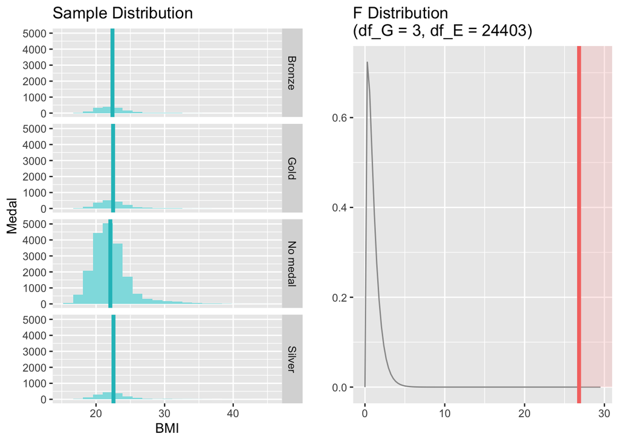

```r
res_aov <- aov(BMI ~ Medal,
  data = df
)

summary(res_aov)
```

```
##                Df Sum Sq Mean Sq F value Pr(>F)
## Medal           3    639  213.11   26.83 <2e-16 ***
## Residuals   24403 193851    7.94
## ---
## Signif. codes:  0 '***' 0.001 '**' 0.01 '*' 0.05 '.' 0.1 ' ' 1
```

```r
post_test <- glht(res_aov,
  linfct = mcp(Medal = "Tukey")
)

summary(post_test)
```

```
##
##   Simultaneous Tests for General Linear Hypotheses
##
## Multiple Comparisons of Means: Tukey Contrasts
##
##
## Fit: aov(formula = BMI ~ Medal, data = df)
##
## Linear Hypotheses:
##                        Estimate Std. Error t value Pr(>|t|)
## Gold - Bronze == 0      0.09133    0.09674   0.944 0.769066
## No medal - Bronze == 0 -0.31187    0.07474  -4.173 0.000183 ***
## Silver - Bronze == 0    0.14828    0.10033   1.478 0.434051
## No medal - Gold == 0   -0.40319    0.06778  -5.949  < 1e-04 ***
## Silver - Gold == 0      0.05695    0.09526   0.598 0.928139
## Silver - No medal == 0  0.46014    0.07281   6.319  < 1e-04 ***
## ---
## Signif. codes:  0 '***' 0.001 '**' 0.01 '*' 0.05 '.' 0.1 ' ' 1
## (Adjusted p values reported -- single-step method)
```

### Using two-tier performance metric

```r
df2 <- df
df2$Medal = ifelse(df$Medal == 'No medal', "No", "Yes")
df2$Medal = as.factor(df2$Medal)

summary(df2)
```

```
##        ID             Sex                 Age            Height
##  Min.   :    34   Length:24407       Min.   :12.00   Min.   :146.0
##  1st Qu.: 34574   Class :character   1st Qu.:20.00   1st Qu.:171.0
##  Median : 69202   Mode  :character   Median :23.00   Median :178.0
##  Mean   : 68716                      Mean   :23.58   Mean   :177.7
##  3rd Qu.:102686                      3rd Qu.:26.00   3rd Qu.:184.0
##  Max.   :135563                      Max.   :52.00   Max.   :208.0
##      Weight         Country               Year         Sport
##  Min.   : 35.00   Length:24407       Min.   :1896   Length:24407
##  1st Qu.: 61.00   Class :character   1st Qu.:1968   Class :character
##  Median : 69.00   Mode  :character   Median :1988   Mode  :character
##  Mean   : 70.54                      Mean   :1983
##  3rd Qu.: 78.00                      3rd Qu.:2004
##  Max.   :160.00                      Max.   :2016
##  Medal            BMI
##  No :19349   Min.   :15.43
##  Yes: 5058   1st Qu.:20.42
##              Median :21.79
##              Mean   :22.17
##              3rd Qu.:23.30
##              Max.   :44.38
```

```r
df2 %>% group_by(Medal) %>%
  summarise(mean = mean(BMI), SD = sd(BMI))
```

```
## # A tibble: 2 × 3
##   Medal  mean    SD
##   <fct> <dbl> <dbl>
## 1 No     22.1  2.85
## 2 Yes    22.5  2.70
```

```r
inference(y = BMI, x = Medal, data = df2, statistic = "mean", type = "ht", null = 0, alternative = "greater", method = "theoretical", order = c("Yes", "No"))
```

```
## Response variable: numerical
## Explanatory variable: categorical (2 levels)
## n_Yes = 5058, y_bar_Yes = 22.4777, s_Yes = 2.697
## n_No = 19349, y_bar_No = 22.0839, s_No = 2.8494
## H0: mu_Yes =  mu_No
## HA: mu_Yes > mu_No
## t = 9.1358, df = 5057
## p_value = < 0.0001
```

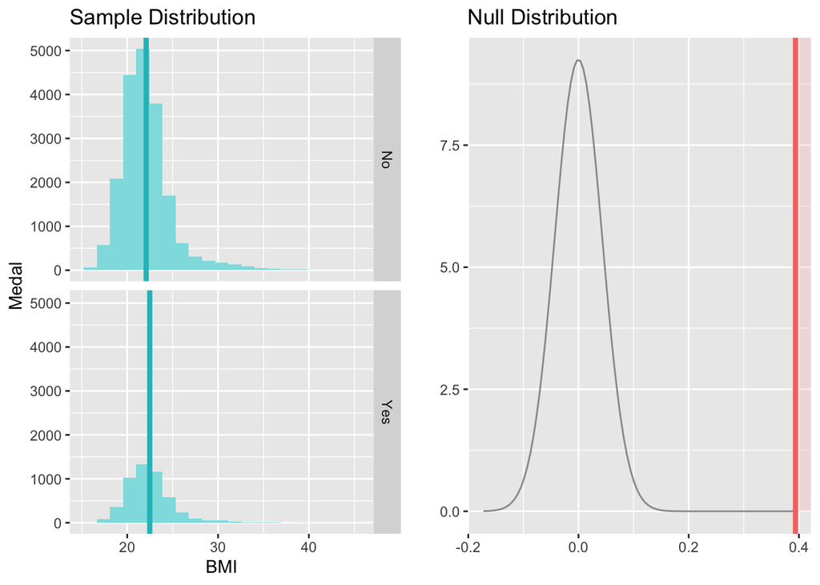

## BMI across different sports

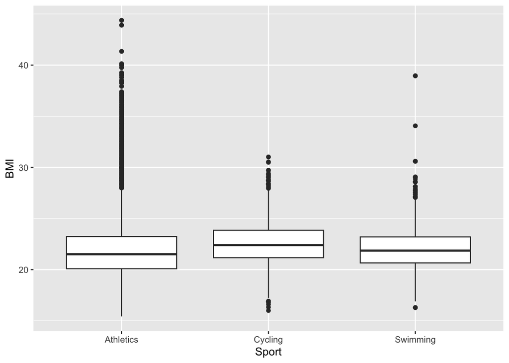

```r
ggplot(df, aes(x = Sport, y = BMI)) + geom_boxplot()
```

```r
inference(y = BMI, x = Sport, data = df, statistic = "mean", type = "ht", conf_level = 0.95, null = 0, alternative = "greater", method = "theoretical")
```

```
## Response variable: numerical
## Explanatory variable: categorical (3 levels)
## n_Athletics = 12603, y_bar_Athletics = 22.1978, s_Athletics = 3.4131
## n_Cycling = 2949, y_bar_Cycling = 22.5832, s_Cycling = 2.2646
## n_Swimming = 8855, y_bar_Swimming = 21.9805, s_Swimming = 1.8934
##
## ANOVA:
##              df      Sum_Sq  Mean_Sq       F  p_value
## Sport         2    830.8822 415.4411 52.3517 < 0.0001
## Residuals 24404  193659.747   7.9356
## Total     24406 194490.6292
##
## Pairwise tests - t tests with pooled SD:
## # A tibble: 3 × 3
##   group1   group2     p.value
##   <chr>    <chr>        <dbl>
## 1 Cycling  Athletics 2.31e-11
## 2 Swimming Athletics 2.66e- 8
## 3 Swimming Cycling   8.89e-24
```

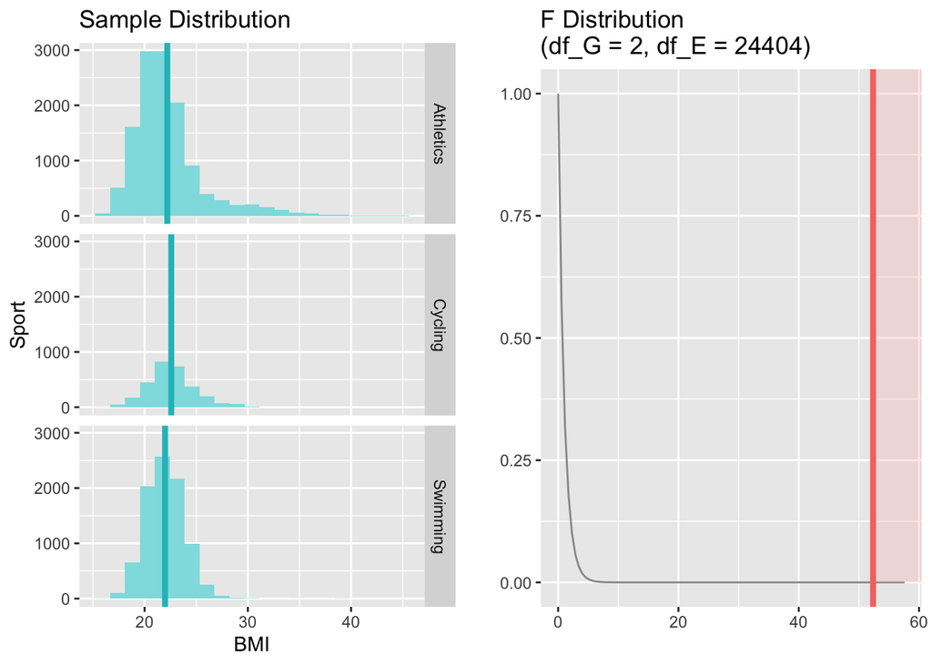